# Dissecting tumor transcriptional heterogeneity from multi-tumor single-cell RNA-seq data using GBCD

2024-05-09

## Overview

This vignette shows how to apply GBCD (“Generalized Binary Covariance Decomposition”) to jointly analyze single-cell RNA-seq (scRNA-seq) data from *malignant cells* collected from multiple patients and/or studies.

GBCD can effectively dissect tumor transcriptional heterogeneity into patient/study-specific and shared gene expression programs (GEPs). GBCD is “unsupervised” in that, unlike tumor-by-tumor (e.g., [Puram et al. 2017](https://doi.org/10.1016/j.cell.2017.10.044)) and many harmonization approaches (e.g., [Harmony](https://portals.broadinstitute.org/harmony/), [LIGER](https://github.com/welch-lab/liger/)), it does not use information about which cell comes from which tumor or study. Instead, GBCD only requires the combined scRNA-seq data from all tumors, which are stored as an $N \times J$ matrix $Y$ of expression values with entries $y_{ij}$, where $i=1,\dots,N$ indexes malignant cells and $j=1,\dots,J$ indexes genes. In typical applications, $Y$ contains “shifted log” counts (following the terminology of [this paper](https://doi.org/10.1038/s41592-023-01814-1)).

GBCD yields a decomposition of the expression data matrix $Y$ into matrices $L$ and $F$ such that $Y \approx L F^T$:
$$y_{ij} \approx \sum_{k=1}^K l_{ik} f_{jk}.$$
The elements $l_{ik} \geq 0$ each represent the membership of cell $i$ in GEP $k$; $f_{jk}$ represents the effect of GEP $k$ on the expression of gene $j$. When $y_{ij}$ are shifted log counts, each $f_{jk}$ approximately represents the log-fold change (LFC) associated with membership in GEP $k$, so we refer to the $f_{jk}$ values as LFCs, and we refer to the vector of LFCs $(f_{1k}, \dots, f_{Jk})^T$ as the “signature” of GEP $k$.

We begin our analysis by loading the needed R packages.

```r
library(Matrix)
library(ggplot2)
library(cowplot)
library(ggrepel)
library(pheatmap)
library(Rtsne)
library(flashier)
devtools::load_all("/Users/yushaliu/Documents/git/gbcd")
```

## The HNSCC dataset

This dataset contained gene expression data for 2,176 malignant cells collected from primary tumors from 10 HNSCC patients and matching lymph node (LN) metastases from 5 of these patients. [Puram et al. (2017)](https://doi.org/10.1016/j.cell.2017.10.044) found that each of these 10 patients clearly mapped to a molecular subtype of HNSCC, whose signatures were previously defined by analysis of bulk expression data of 279 [TCGA](https://doi.org/10.1038/nature14129) HNSCC tumors. [Puram et al. (2017)](https://doi.org/10.1016/j.cell.2017.10.044) defined the transformed counts as $y_{ij} = \log_2(1 + \mathrm{TPM}_{ij}/10)$, where $\mathrm{TPM}_{ij}$ was the transcript-per-million (TPM) value for gene $j$ in cell $i$.

```r
data(hnscc)
Y <- hnscc$Y
info <- hnscc$info
dim(Y)
head(info)
# make sure the rows of Y and info match
sum(rownames(Y)!=rownames(info))
# [1]  2176 17113
#                                             cell.id lymph.node cancer.cell
# HN26_P14_D11_S239_comb       HN26_P14_D11_S239_comb          1           1
# HN26_P25_H09_S189_comb       HN26_P25_H09_S189_comb          1           1
# HN26_P14_H06_S282_comb       HN26_P14_H06_S282_comb          1           1
# HN25_P25_C04_S316_comb       HN25_P25_C04_S316_comb          1           1
# HN26_P25_C09_S129_comb       HN26_P25_C09_S129_comb          1           1
# HNSCC26_P24_H05_S377_comb HNSCC26_P24_H05_S377_comb          1           1
#                           cell.type patient.id    sample  subtype
# HN26_P14_D11_S239_comb            0        T26 MEEI26_LN Atypical
# HN26_P25_H09_S189_comb            0        T26 MEEI26_LN Atypical
# HN26_P14_H06_S282_comb            0        T26 MEEI26_LN Atypical
# HN25_P25_C04_S316_comb            0        T25 MEEI25_LN    Basal
# HN26_P25_C09_S129_comb            0        T26 MEEI26_LN Atypical
# HNSCC26_P24_H05_S377_comb         0        T26 MEEI26_LN Atypical
# [1] 0
```

## Visualize HNSCC data using t-SNE

We plot the 2-D *t*-SNE embedding of the 2,176 malignant cells, colored by patient-of-origin and tumor stage (primary tumor, LN metastasis), and shaped is varied by tumor molecular subtype. Due to the presence of strong inter-tumor heterogeneity, these cells demonstrate strong patient effects that are typical of cancer data; the major structure in the t-SNE visualization is the clustering of the cells by patient:

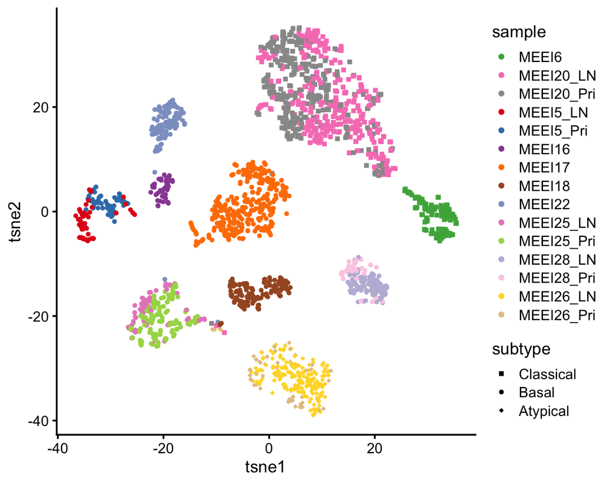

```r
set.seed(1)
cols <- order(apply(Y,2,sd),decreasing = TRUE)
cols <- cols[1:3000]
res  <- Rtsne(as.matrix(Y[,cols]),normalize = TRUE)
colnames(res$Y) <- c("tsne1","tsne2")
pdat <- cbind(res$Y,info)
ggplot(pdat,aes(x = tsne1,y = tsne2,color = sample,shape = subtype)) +
  geom_point(size = 1) + scale_color_manual(values = hnscc$sample_col) +
  scale_shape_manual(values = c(15,16,18)) +
  theme_cowplot(font_size = 10)
```

## Estimate GEP memberships and signatures using GBCD

To fit a GBCD model, “Kmax” needs to set. It is an upper bound of the number of components, $K$. This is just for initialization purposes; the final number of GEPs returned by GBCD is close to but often not equal to (and can be larger than) Kmax. Generally speaking, a larger Kmax allows for identifying finer structure in tumor transcriptional heterogeneity, at the expense of higher computational cost. A good choice of Kmax depends on the complexity of the analyzed data (e.g., the number of patients and studies contained), and is often unknown in advance. Based on our experience, a value of Kmax between 10 and 40 usually works well, and users are encouraged to explore and compare the results for different values of Kmax.

Users also need to specify a prior for GEP membership values. GBCD assigns a “generalized binary” (GB) prior independently to each entry of $L$,
$$l_{ik}\sim (1-\pi_k^l) \delta_0 + \pi_k^l \:
N_{+} (\mu_k,
\sigma_k^2),$$
where the ratio $\sigma_k/\mu_k$ is fixed at some pre-specified small value. In this application, we set $\sigma_k/\mu_k = 0.04$ for each $k$. A smaller ratio is generally recommended for larger datasets containing more cells, and a value between 0.01 to 0.1 usually works well.

Note that the patient/dataset identity information of cells is *not* needed to run GBCD.

For the purposes of reducing the running time, here we set `Kmax = 12`, and we limit the number of backfitting iterations to `maxiter1 = 100` (for initializing L), `maxiter2 = 50` (for estimating L), and `maxiter3 = 50` (for estimating F).

```r
res.gbcd <- fit_gbcd(Y = Y, Kmax = 12, maxiter1 = 100,
                     maxiter2 = 50, maxiter3 = 50,
                     prior = flash_ebnm(prior_family = "generalized_binary",
                                        scale = 0.04))
# [1] "Form cell by cell covariance matrix..."
#    user  system elapsed
#  15.128   0.033  15.229
# [1] "Initialize GEP membership matrix L..."
# Adding factor 1 to flash object...
# Wrapping up...
# Done.
# Adding factor 2 to flash object...
# Adding factor 3 to flash object...
# Adding factor 4 to flash object...
# Adding factor 5 to flash object...
# Adding factor 6 to flash object...
# Adding factor 7 to flash object...
# Adding factor 8 to flash object...
# Adding factor 9 to flash object...
# Adding factor 10 to flash object...
# Adding factor 11 to flash object...
# Adding factor 12 to flash object...
# Wrapping up...
# Done.
# Backfitting 12 factors (tolerance: 7.06e-02)...
#   Difference between iterations is within 1.0e+04...
#   Difference between iterations is within 1.0e+03...
#   Difference between iterations is within 1.0e+02...
#   --Maximum number of iterations reached!
# Wrapping up...
# Done.
# Backfitting 12 factors (tolerance: 7.06e-02)...
#   Difference between iterations is within 1.0e+04...
#   Difference between iterations is within 1.0e+03...
#   Difference between iterations is within 1.0e+02...
#   Difference between iterations is within 1.0e+01...
#   --Maximum number of iterations reached!
# Wrapping up...
# Done.
#    user  system elapsed
#  42.548   2.874  45.667
# [1] "Estimate GEP membership matrix L..."
# Backfitting 23 factors (tolerance: 7.06e-02)...
#   Difference between iterations is within 1.0e+05...
#   Difference between iterations is within 1.0e+04...
#   Difference between iterations is within 1.0e+03...
#   --Maximum number of iterations reached!
# Wrapping up...
# Done.
# Backfitting 23 factors (tolerance: 7.06e-02)...
#   Difference between iterations is within 1.0e+03...
#   Difference between iterations is within 1.0e+02...
#   --Maximum number of iterations reached!
# Wrapping up...
# Done.
#    user  system elapsed
#  72.802   3.134  76.264
# [1] "Estimate GEP signature matrix F..."
# Backfitting 23 factors (tolerance: 5.55e-01)...
#   Difference between iterations is within 1.0e+03...
#   Difference between iterations is within 1.0e+02...
#   --Maximum number of iterations reached!
# Wrapping up...
# Done.
#    user  system elapsed
# 331.383  13.242 346.126
```

Note that users can also specify other nonnegative priors for GEP membership values. For example, users can specify a point exponential prior by setting `prior = ebnm_point_exponential` in the call to `fit_gbcd`. However, we find that the GB prior usually performs the best empirically to dissect tumor transcriptional heterogeneity from multiple samples and/or studies.

Note that the above call to `fit_gbcd` may take 10 minutes or slightly longer to complete on a laptop with 24GB RAM.

## Interpret GEP membership estimates

We now look at the GEP membership estimates $L$, in which elements $l_{ik}$ represent membership of cell $i$ in GEP $k$. For example these are the memberships for the first few cells:

```r
head(round(res.gbcd$L, 3))
#                           Baseline GEP1  GEP2  GEP3  GEP4  GEP5  GEP6  GEP7
# HN26_P14_D11_S239_comb       0.735    0 0.000 0.895 0.354 0.000 0.000 0.573
# HN26_P25_H09_S189_comb       0.657    0 0.141 0.776 0.000 0.479 0.000 0.617
# HN26_P14_H06_S282_comb       0.791    0 0.244 0.710 0.606 0.000 0.000 0.713
# HN25_P25_C04_S316_comb       0.412    0 0.661 0.212 0.000 0.649 0.000 0.000
# HN26_P25_C09_S129_comb       0.645    0 0.000 0.743 0.000 0.382 0.000 0.733
# HNSCC26_P24_H05_S377_comb    0.586    0 0.000 0.739 0.000 0.405 0.345 0.696
#                           GEP8  GEP9 GEP10 GEP11 GEP12 GEP13 GEP14 GEP15 GEP16
# HN26_P14_D11_S239_comb       0 0.000 0.664     0     0 0.437 0.000 0.000 0.000
# HN26_P25_H09_S189_comb       0 0.000 0.000     0     0 0.471 0.000 0.591 0.000
# HN26_P14_H06_S282_comb       0 0.000 0.000     0     0 0.452 0.000 0.000 0.585
# HN25_P25_C04_S316_comb       0 0.695 0.672     0     0 0.606 0.793 0.670 0.000
# HN26_P25_C09_S129_comb       0 0.000 0.000     0     0 0.000 0.000 0.748 0.000
# HNSCC26_P24_H05_S377_comb    0 0.000 0.000     0     0 0.000 0.461 0.586 0.000
#                           GEP17 GEP18 GEP19 GEP20
# HN26_P14_D11_S239_comb        0  0.00     0     0
# HN26_P25_H09_S189_comb        0  0.00     0     0
# HN26_P14_H06_S282_comb        0  0.36     0     0
# HN25_P25_C04_S316_comb        0  0.00     0     0
# HN26_P25_C09_S129_comb        0  0.00     0     0
# HNSCC26_P24_H05_S377_comb     0  0.00     0     0
```

Let’s create a heatmap to visualize GEP membership estimates. First we add the sample and molecular subtype annotation of cells to visualize the GEP memberships:

```r
anno <- data.frame(sample=info$sample, subtype=info$subtype)
rownames(anno) <- rownames(res.gbcd$L)
anno_colors <- list(sample=hnscc$sample_col, subtype=hnscc$subtype_col)
cols <- colorRampPalette(c("gray96", "red"))(50)
brks <- seq(0, 1, 0.02)
```

Now we can plot the annotated heatmap of GEP memberships:

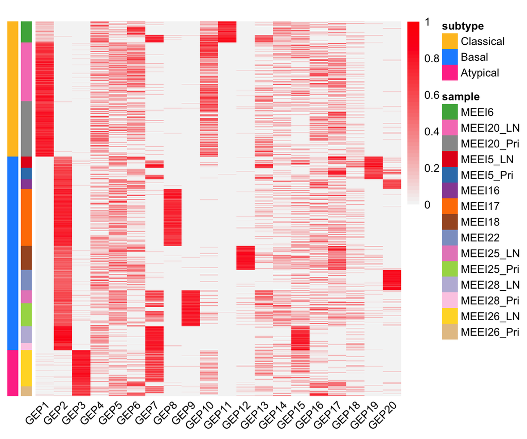

```r
pheatmap(res.gbcd$L[order(anno$sample), -c(1)], cluster_rows = FALSE,
         cluster_cols = FALSE, show_rownames = FALSE, annotation_row = anno,
         annotation_colors = anno_colors, annotation_names_row = FALSE,
         angle_col = 45, fontsize = 9, color = cols, breaks = brks,
         main = "")
```

This heatmap shows the memberships of the 2,176 cells (rows) for the 20 GEPs (the “baseline” is not included). Cells are arranged top-to-bottom by tumor molecular subtype and by patient-of-origin. Membership values are rescaled separately for GEPs so that the maximum membership value for each GEP is always 1.

From this heatmap, we see that GEPs 1-3 correspond closely to the molecular subtypes previously defined based on bulk RNA-seq data: GEP1 is largely active only in cells from the 2 classical patients; GEP2 is mainly active in cells from the 7 basal patients; and GEP3 is mainly active in cells from the one atypical patient. This demonstrates that GBCD can extract the molecular subtype information *de novo* from the single cell data alone.

Among other GEPs, some are active predominantly in an individual patient and can thus be interpreted as patient-specific GEPs, such as GEPs 8, 9 and 11; other GEPs are shared across patients but do not correspond to molecular subtypes. The degree of patient-specific vs. shared expression for each GEP can be quantified using the “gep_annotation” function.

## GEP signature estimates

We next look at the matrix of GEP signature estimates $F$ with each entry $f_{jk}$ approximately representing the log-fold change associated with membership in GEP $k$ (with the base-2 logarithm).

```r
head(round(res.gbcd$F$lfc, 3))
#              Baseline   GEP1   GEP2   GEP3   GEP4   GEP5   GEP6   GEP7   GEP8
# C9orf152        0.000  0.064  0.000  0.004  0.000  0.003  0.000  0.000  0.000
# ELMO2           2.056  0.000 -0.466  0.715  0.003 -0.273 -0.065  0.015 -0.051
# PNMA1           1.933  0.003 -1.326  0.035 -0.002  0.019 -0.043 -0.019 -0.018
# MMP2            0.763 -0.468  2.441 -0.897 -0.005  0.786 -0.597 -0.004 -1.206
# TMEM216         2.141  1.046 -0.652  0.021  0.006 -0.012 -0.115 -0.021 -0.002
# TRAF3IP2-AS1    0.216  0.293  0.000  0.588  0.001  0.132  0.000  0.003  0.000
#               GEP9  GEP10  GEP11  GEP12 GEP13  GEP14  GEP15  GEP16  GEP17
# C9orf152     0.000 -0.003 -0.004  0.000 0.002  0.084  0.000  0.000  0.000
# ELMO2        0.081  0.005 -0.764 -0.036 0.348 -0.352 -0.566 -0.019 -0.003
# PNMA1        2.154  0.065 -0.017  0.339 0.731  0.012 -0.048  0.014 -0.002
# MMP2         0.051 -0.031  0.026 -0.867 0.800  0.348 -0.508  0.035 -0.297
# TMEM216      1.137 -0.088 -0.401 -0.262 0.189 -0.605 -0.013 -0.429 -0.055
# TRAF3IP2-AS1 0.005  0.013  0.011 -0.004 0.025  0.449 -0.002  0.019 -0.001
#               GEP18  GEP19  GEP20
# C9orf152      0.014 -0.001  0.000
# ELMO2        -0.104  0.060  0.019
# PNMA1        -0.007 -0.008  0.022
# MMP2         -1.498 -0.020  3.791
# TMEM216      -0.037 -0.012  0.029
# TRAF3IP2-AS1 -0.002  0.042 -0.001
```

Here we create a volcano plot to visualize the gene signature for a given GEP (using GEP2 as an example). This plot makes use of posterior statistics outputted by the `fit_gbcd` call, including the z-scores and the local false sign rates ([*lfsr*](https://doi.org/10.1093/biostatistics/kxw041)).

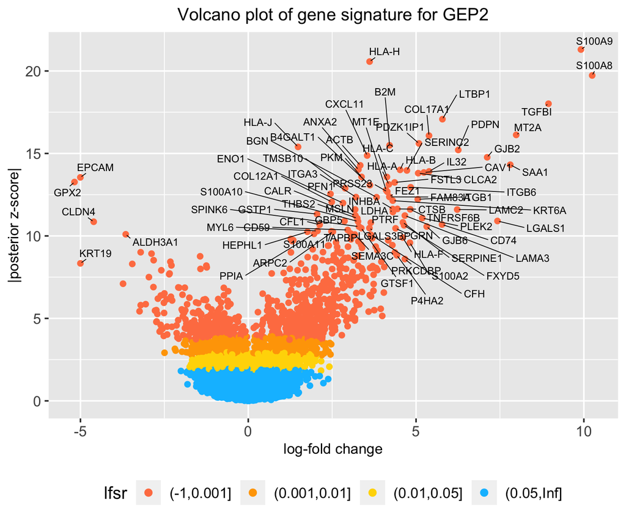

```r
pdat <- data.frame(gene = rownames(res.gbcd$F$lfc),
                   lfc = res.gbcd$F$lfc[, "GEP2"],
                   z = abs(res.gbcd$F$z_score[, "GEP2"]),
                   lfsr = res.gbcd$F$lfsr[, "GEP2"],
                   stringsAsFactors = FALSE)
pdat <- transform(pdat, lfsr = cut(lfsr, c(-1, 0.001, 0.01, 0.05, Inf)))
rows  <- with(pdat, which(!(abs(lfc) > quantile(abs(lfc), 0.998) | (z > 10))))
pdat[rows, "gene"] <- ""
ggplot(pdat, aes(x = lfc, y = z, color = lfsr, label = gene)) + geom_point() +
  geom_text_repel(color = "black", size = 2.5, segment.color = "black",
                  segment.size = 0.25, min.segment.length = 0,
                  max.overlaps = Inf, na.rm = TRUE) +
  scale_color_manual(values = c("coral", "orange", "gold", "deepskyblue")) +
  labs(x = "log-fold change", y = "|posterior z-score|") +
  guides(colour = guide_legend(override.aes = list(size = 2))) +
  theme(plot.title      = element_text(hjust = 0.5,size = 12),
        axis.text       = element_text(size = 10),
        axis.title      = element_text(size = 10),
        legend.title    = element_text(size = 12),
        legend.text     = element_text(size = 10),
        legend.position = "bottom") +
  ggtitle("Volcano plot of gene signature for GEP2")
```

## Session info

This was the version of R and the packages that were used to generate these results.

```r
sessionInfo()
# R version 4.3.1 (2023-06-16)
# Platform: aarch64-apple-darwin20 (64-bit)
# Running under: macOS Sonoma 14.3
#
# Matrix products: default
# BLAS:   /Library/Frameworks/R.framework/Versions/4.3-arm64/Resources/lib/libRblas.0.dylib
# LAPACK: /Library/Frameworks/R.framework/Versions/4.3-arm64/Resources/lib/libRlapack.dylib;  LAPACK version 3.11.0
#
# locale:
# [1] en_US.UTF-8/en_US.UTF-8/en_US.UTF-8/C/en_US.UTF-8/en_US.UTF-8
#
# time zone: America/New_York
# tzcode source: internal
#
# attached base packages:
# [1] stats     graphics  grDevices utils     datasets  methods   base
#
# other attached packages:
# [1] gbcd_0.1-17     flashier_1.0.53 ebnm_1.1-26     Rtsne_0.16
# [5] pheatmap_1.0.12 ggrepel_0.9.3   cowplot_1.1.1   ggplot2_3.4.3
# [9] Matrix_1.6-1
#
# loaded via a namespace (and not attached):
#   [1] pbapply_1.7-2        remotes_2.4.2.1      rlang_1.1.1
#   [4] magrittr_2.0.3       horseshoe_0.2.0      compiler_4.3.1
#   [7] callr_3.7.3          vctrs_0.6.3          stringr_1.5.0
#  [10] profvis_0.3.8        quantreg_5.97        quadprog_1.5-8
#  [13] pkgconfig_2.0.3      crayon_1.5.2         fastmap_1.1.1
#  [16] mcmc_0.9-7           ellipsis_0.3.2       labeling_0.4.3
#  [19] utf8_1.2.3           promises_1.2.1       rmarkdown_2.24
#  [22] sessioninfo_1.2.2    ps_1.7.5             MatrixModels_0.5-2
#  [25] purrr_1.0.2          xfun_0.40            cachem_1.0.8
#  [28] trust_0.1-8          jsonlite_1.8.7       progress_1.2.2
#  [31] later_1.3.1          irlba_2.3.5.1        parallel_4.3.1
#  [34] prettyunits_1.1.1    R6_2.5.1             stringi_1.7.12
#  [37] bslib_0.5.1          RColorBrewer_1.1-3   SQUAREM_2021.1
#  [40] pkgload_1.3.2.1      jquerylib_0.1.4      Rcpp_1.0.11
#  [43] knitr_1.44           usethis_2.2.2        httpuv_1.6.11
#  [46] splines_4.3.1        tidyselect_1.2.0     rstudioapi_0.15.0
#  [49] yaml_2.3.7           miniUI_0.1.1.1       processx_3.8.2
#  [52] pkgbuild_1.4.2       lattice_0.21-8       tibble_3.2.1
#  [55] shiny_1.7.5          withr_2.5.0          coda_0.19-4
#  [58] evaluate_0.21        desc_1.4.2           survival_3.5-7
#  [61] urlchecker_1.0.1     RcppParallel_5.1.7   pillar_1.9.0
#  [64] plotly_4.10.2        softImpute_1.4-1     generics_0.1.3
#  [67] rprojroot_2.0.3      invgamma_1.1         truncnorm_1.0-9
#  [70] hms_1.1.3            munsell_0.5.0        scales_1.2.1
#  [73] ashr_2.2-63          xtable_1.8-4         glue_1.6.2
#  [76] scatterplot3d_0.3-44 lazyeval_0.2.2       tools_4.3.1
#  [79] data.table_1.14.8    SparseM_1.81         fs_1.6.3
#  [82] grid_4.3.1           tidyr_1.3.0          MCMCpack_1.6-3
#  [85] devtools_2.4.5       colorspace_2.1-0     deconvolveR_1.2-1
#  [88] cli_3.6.1            Polychrome_1.5.1     fansi_1.0.4
#  [91] mixsqp_0.3-48        viridisLite_0.4.2    dplyr_1.1.3
#  [94] uwot_0.1.16          gtable_0.3.4         fastTopics_0.6-142
#  [97] sass_0.4.7           digest_0.6.33        farver_2.1.1
# [100] htmlwidgets_1.6.2    memoise_2.0.1        htmltools_0.5.6
# [103] lifecycle_1.0.3      httr_1.4.7           mime_0.12
# [106] MASS_7.3-60
```